# Basic statistics - chi-square test

Elizabeth Oladapo

Last modified: 2 September 2023

In this session, we will delve into enhancing your understanding of how to perform statistical analyses for addressing questions related to frequency data. One crucial point to keep in mind is that frequency data are counts, not proportions or means.

### **What is a chi-square test?**

A chi-squared test (also chi-square or χ2 test) is a statistical test that is used to compare observed and expected results. The goal of this test is to identify whether a disparity between actual and predicted data is due to chance or to a link between the variables under consideration.

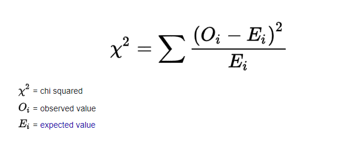

**Example of exploring the association test (Chi-Square) manually**

- Calculate the Expected Values:

- Compute the Chi-Square Statistic:

For each cell, find the Chi-Square value using the formula:

- Sum up all the Chi-Square values to obtain the total Chi-Square statistic.
- Evaluate Association:

Compare the total Chi-Square statistic to a Chi-Square distribution table to determine if it is statistically significant. If the Chi-Square statistic is greater than the critical value, it suggests an association between the variables.

- Null Hypothesis:

The null hypothesis assumes that within the categorical variables, there are equal proportions, implying no association between them.

**We will maintain our data analysis pipeline:**

- Visualize the data.
- Develop a model that aligns with your research question and is reflected in your graphical representation.
- Assess the assumptions.
- Draw inferences.

We will use the “cars.csv” dataset to perform a 2 x 2 contingency table analysis using a Chi-square contingency table test. This dataset contains counts of expensive and cheap cars in urban and rural environments. The primary question is: Does an association/interaction exist between the worth of cars and the environment where they are found?

### **Visualize the data**

To further solidify our understanding, let us visualize our sample dataset “cars.csv”.

```r
# Load the tidyverse library, including ggplot2 and dplyr
library(tidyverse)
# Load the datasets into R
cars <- read_csv("data/cars.csv")
```

Let us generate a summary of information, as depicted below.

```r
summary_cars <- cars %>%
  group_by(environment,worth) %>%
  summarize(number = sum(number))
summary_cars
```

```
## # A tibble: 4 x 3
## # Groups:   environment [2]
##   environment worth     number
##   <chr>       <chr>      <dbl>
## 1 Rural       cheap        210
## 2 Rural       expensive     90
## 3 Urban       cheap        255
## 4 Urban       expensive    345
```

Plot the data: stacked versus unstacked graphs. When is a barplot justified? Only with count data.

Contingency table data, particularly count data, is one of the few types of data where using bar charts is justified. This is because these counts range from zero up to a specific number, representing a straightforward count without any summary statistics or estimates of variation. However, there are a few challenges we need to address:

Color Adjustment: First, we need to ensure that the colors of the bars correspond correctly to our categories, specifically red and black.

Bar Stacking: Second, we should arrange the bars side by side, rather than stacked on top of each other.

Let’s tackle these issues step by step using R code:

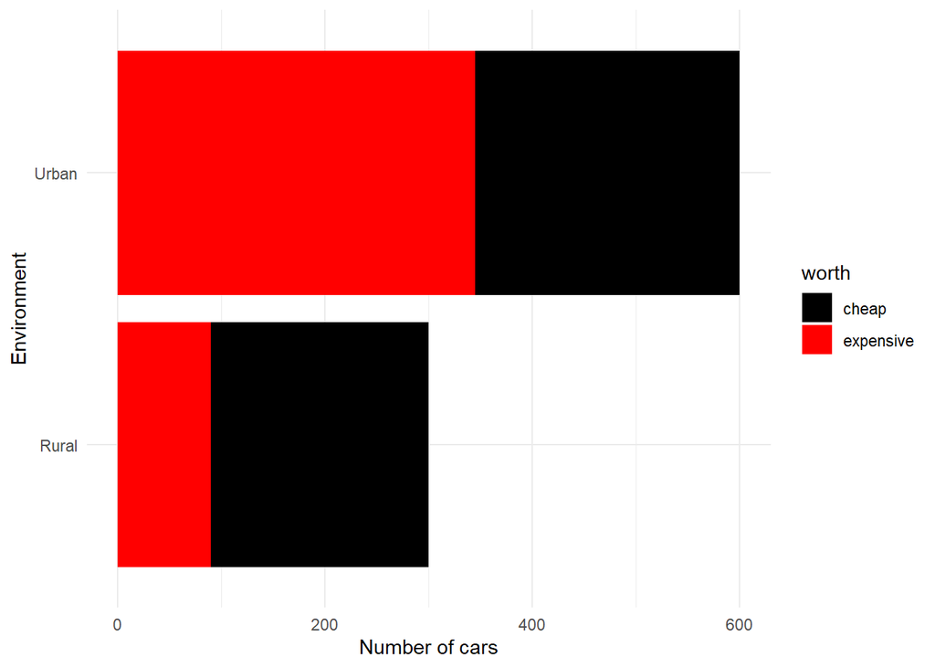

```r
# Stacked
ggplot(summary_cars, aes(x = environment, y = number, fill = worth)) +
  geom_col() +
  scale_fill_manual(values = c(expensive = "red", cheap = "black")) +
  labs(x = "Environment", y = "Number of cars") +
  theme_minimal() +
  coord_flip() # Rotate the chart for better visualization
```

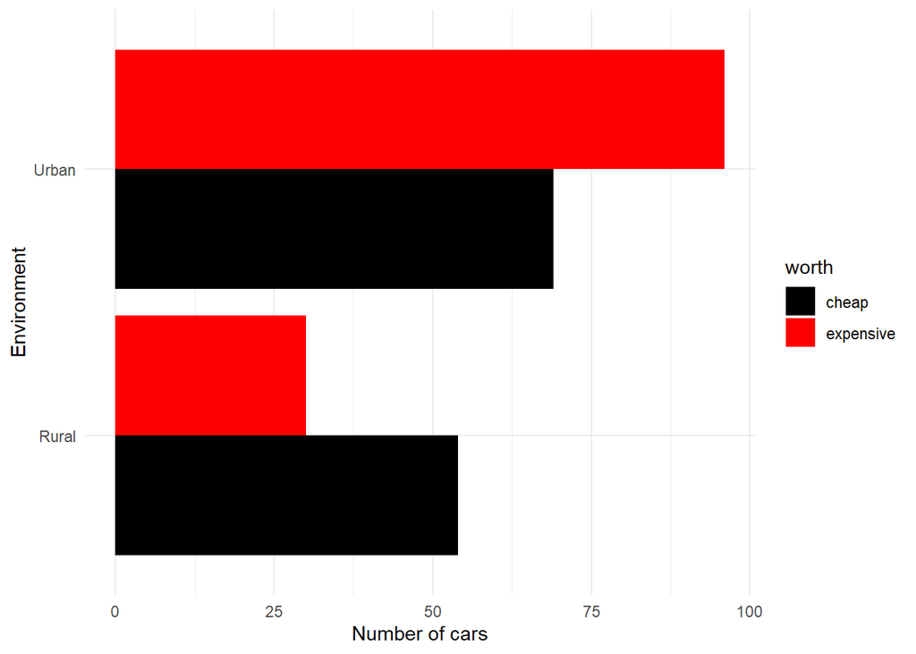

```r
# Unstacked
ggplot(cars, aes(x = environment, y = number, fill = worth)) +
  geom_col(position = "dodge") +
  scale_fill_manual(values = c(expensive = "red", cheap = "black")) +
  labs(x = "Environment", y = "Number of cars") +
  theme_minimal() +
  coord_flip() # Rotate the chart for better visualization
```

**There are a few key takeaways:**

Valid Use of Bar Plots: Bar plots are highly suitable for visualizing count data, especially when dealing with contingency table analysis.

Customizing Colors with Fill or Scale Color Manual: The importance of utilizing “fill” or “scale_color_manual” becomes evident as it empowers you to tailor your graphs, ensuring that the right colors are associated with the correct levels or categories within your categorical variable.

Position Argument in Geom Call: The clever use of the “position = dodge” argument within “geom_col()” allows you to position bars side by side instead of having them stacked on top of each other.

### **Perform chi_square test**

The chi-square test does not determine whether there are a greater or lesser number of expensive or cheap cars in each of these environments. As we observed in the visualizations, there are indeed more cars in urban cities compared to rural ones. However, this test is not assessing that aspect. Instead, it is examining a different question: Does an association exist? Specifically, are there variations in the number of one car category compared to the other between the two environments? In other words, this chi-square test is designed to investigate whether there is a significant correlation between the car’s worth and their respective environments. It aims to answer whether one environment tends to have more or fewer individuals of a particular car compared to the other environment

We cannot perform the chi-square test directly with our current data format. The chi-square test requires a different data structure than the tidy format we have used for our visualizations. This test thrives on a specific data format, known as a matrix or contingency table, which gives rise to the name “chi-squared contingency table analysis.”

To convert our existing data into this matrix format, we employ a function called “xtabs” which uses cross-tabulation to create a matrix from the dataset.

```r
# Create a contingency table using the 'xtabs()' function

cars_mat <- xtabs(number ~ environment + worth, data = cars)
cars_mat
```

```
##            worth
## environment cheap expensive
##       Rural   210        90
##       Urban   255       345
```

```r
# The contingency_table, "cars_mat" now contains the matrix format required for the chi-square test
```

Here is how you can execute the chi-squared test using R:

```r
# Perform the chi-square test and store the results in 'cars_mod'

cars_mod <- chisq.test(cars_mat)

# To inspect the results, simply type 'cars_mod' which will display information about the Pearson's chi-square test, including any continuity correction if applied. This allows you to assess the statistical significance of the associations in your data.

cars_mod
```

```
##
##  Pearson's Chi-squared test with Yates' continuity correction
##
## data:  cars_mat
## X-squared = 59.471, df = 1, p-value = 1.241e-14
```

```r
# To see the pieces of the chi-square test

names(cars_mod)
```

```
## [1] "statistic" "parameter" "p.value"   "method"    "data.name" "observed"
## [7] "expected"  "residuals" "stdres"
```

```r
# Access some of these named objects using a dollar sign

cars_mod$"p.value"
```

```
## [1] 1.241046e-14
```

```r
cars_mod$statistic
```

```
## X-squared
##  59.47108
```

```r
cars_mod$expected
```

```
##            worth
## environment cheap expensive
##       Rural   155       145
##       Urban   310       290
```

```r
cars_mod$observed
```

```
##            worth
## environment cheap expensive
##       Rural   210        90
##       Urban   255       345
```

### **Interpreting the results**

First, let’s look at our chi-square statistic, which is 59.471 (the degree of deviation away from the null hypothesis) and the p-value which is 1.241e-14.

This statistic helps us determine whether we accept or reject the null hypothesis.

Now, the question is: under the null hypothesis (no association), how likely is it that we would observe the pattern we see, or something even more extreme?

The answer is that it is highly unlikely. Therefore, we can confidently reject the null hypothesis, indicating a strong association.

**For emphasis**, the smaller the p-value is and the larger the test statistic, the more we lean toward rejecting the null hypothesis in favor of the alternative, which suggests an association.

Now, if you are curious about **Yates’s continuity correction**, you can find information about it in the R help documentation. Here is how to access it:

```
help(chisq.test)
```

The Yates continuity correction is similar to the concept of Welch’s test correction in that it addresses certain underlying assumptions. In the case of Welch’s test, we knew it was employed when dealing with unequal variances. The Yates continuity correction, however, is specifically tailored for two-by-two contingency tables and is consistently applied in such scenarios.

The reason behind its application is the potential presence of low numbers within the cells of the contingency table. Let us revisit the matrix to illustrate this.

```r
cars_mat
```

```
##            worth
## environment cheap expensive
##       Rural   210        90
##       Urban   255       345
```

If any of these cell values falls below 10, it introduces bias into the chi-square test for squared contingency tables. The Yates continuity correction aims to rectify this bias.

In essence, it is a correction designed for situations where at least one cell contains a small count, typically 10 or fewer observations.

It is important to note that for more complex matrices, such as three-by-three or two-by-three tables, a different approach involving Monte Carlo simulations is used instead of the continuity correction.

However, rest assured that regardless of the table’s complexity, there are specialized methods to address the issue of small numbers in at least one cell, as this can violate certain assumptions underlying the chi-square test.

In summary, the Yates continuity correction is an adjustment applied when dealing with two-by-two contingency tables to mitigate bias caused by low cell counts, ensuring the reliability of the chi-square test results.

Fabulous! That’s all for this session. Here are the [solutions](https://lizzydapsy.github.io/R-course_materials/Solutions.html) to all the exercises.

**We are now ready for the next stage.**

**Return** to the [main course page](https://lizzydapsy.github.io/R-for-Data-Analysis/README.html) and click on “Linear Models - Linear regrssion”.